# Презентация по лабораторной работе №1

Методы кодирования и модуляция сигналов

Лушин А.А.

Российский университет дружбы народов, Москва, Россия

Факультет Физико-математических и естественных наук

18 февраля 2005

# Информация

## Докладчик

- Лушин Артём Андреевич
- Бакалавр направления компьютерные и информационные науки
- Кафедра теории вероятности и кибербезопасности
- Российский университет дружбы народов
- Редактор Первого Федерального канала
- lusin5745@gmail.com

# Вводная часть

## Цели и задачи

Изучение методов кодирования и модуляции сигналов с помощью высокоуровнего языка программирования Octave. Определение спектра и параметров сигнала. Демонстрация принципов модуляции сигнала на примере аналоговой амплитудной модуляции. Исследование свойства самосинхронизации сигнала.

# Ход работы

## Простейший график

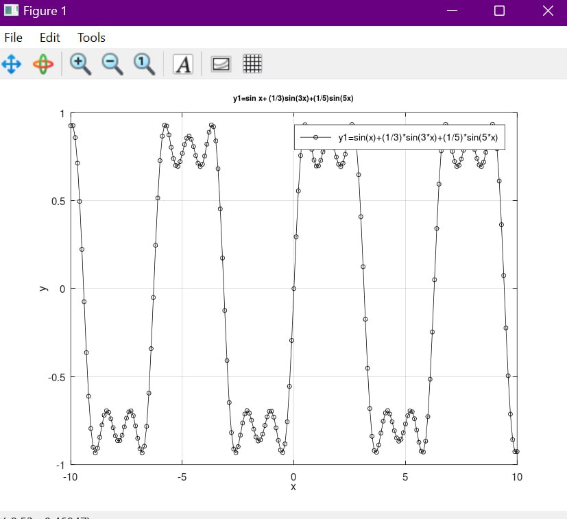

## Частичный ряд Фурье

Написали код, который строит график меандры, используя разное количество гармоник. Разложенный импульсный сигнал в форме меандра можно задать в виде частичного ряд Фурье.

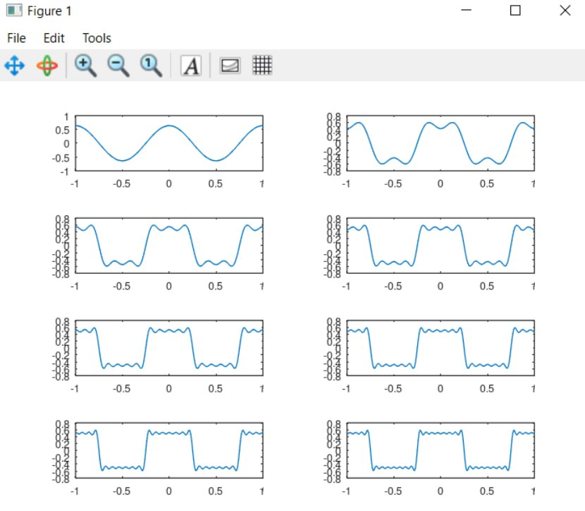

## Спектр и параметр сигналов

Мы создали новый файл и задали два синосоидальных сигнала разной частоты. С помощью преобразования Фурье нашли спектры сигналов. Отбросили дублирующие отрицательные частоты. Создали новый каталог для поиска суммы спектров. По ходу выполнения команд поняли, что спектр суммы сигналов равен сумме спектров сигнала.

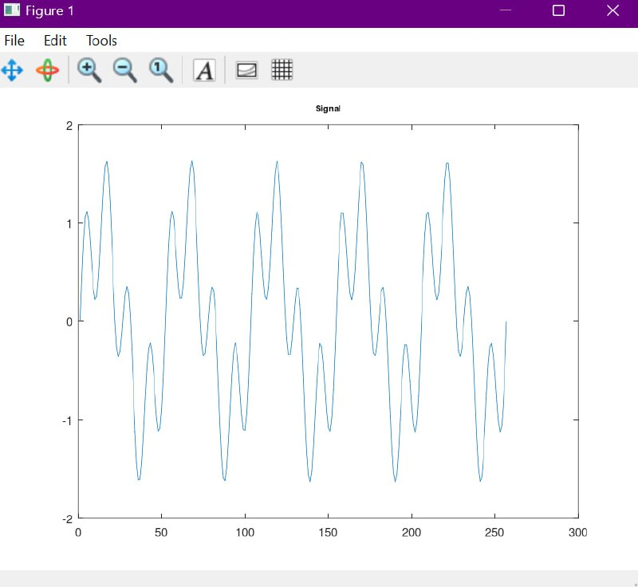

## Амплитудная модуляция

Вновь создали новый файл для модуляции сигналов. После запуска скрипта провели модуляцию и поняли, что спектр произведений представляет свёртку спектров.

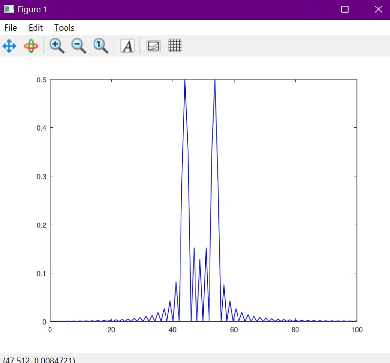

## Кодирование сигнала

Создали 9 файлов для работы: main.m, maptowave.m,unipolar.m,ami.m,bipolarnrz.m,bipolarrz.m,manchester.m, diffmanc.m, calcspectre.m. По ходу выполнения кодов во всех файлах мы получим 3 каталога с разными фотографиями: в каталоге signal файлы с графиками кодированного сигнала, в каталоге sync файлы с графиками, иллюстрирующими свойства самосинхронизации, в каталоге spectre — файлы с графиками спектров сигналов.

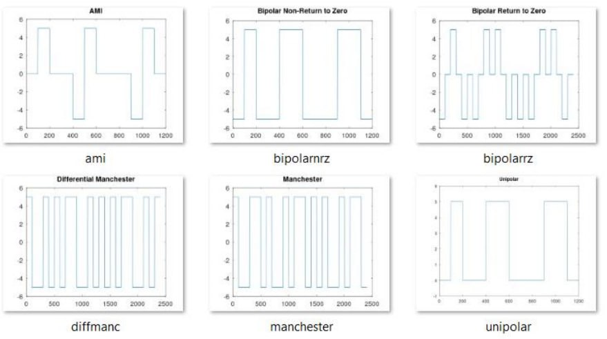

# Результаты

## Вывод

Я изучил методы кодирования и модуляции сигналов с помощью языка Octave. Определил спектры и параметры сигнала. Продемонстрировал принципы модуляции сигналов на примере аналоговой амплитудной модуляции. Исследовал свойства самосинхронизации сигнала.